# Spotify Unwrapped: CMSC320 Edition

## Introduction and Motivation

Spotify is a great way to stream a wide variety of music. With over 30 million songs to stream from, a user can quickly rack up a huge library of songs. It is very easy to just favorite hundreds of songs as you listen. After a couple hundred songs it can almost seem impossible to organize your library into playlists. This is where data science comes in handy! By the end of this tutorial you will have used machine learning in order to cluster your library into different playlists based on the audio features of your playlist's songs. From there, you'll also be able to discover new music by generating playlists with recommended songs.

On top of the organization this tutorial brings, analyzing spotify data will give you a greater sense of the characteristics of your library. You can learn more about yourself by analyzing certain characteristics of your music: Do you like more 'dancey' songs? Or are you more of an instrumental type of listener? All these questions plus more will be explored by the end of the tutorial.

## Required Libraries

This project requires a basic understanding of python. However, If you are not familiar with the language itself but are a strong programmer you should be able to follow along! Before continuing, please familiarize yourself with the following libraries as they will be used heavily:

[Pandas](https://pandas.pydata.org/pandas-docs/version/0.15/tutorials.html), for storing and manipulating data in dataframes.

[Spotipy](https://spotipy.readthedocs.io/en/latest/#), for easily working with the [Spotify API](https://developer.spotify.com/documentation/web-api/).

[Numpy](https://docs.scipy.org/doc/numpy/reference/), for more powerful arrays.

[Scikit-learn](https://scikit-learn.org/stable/), for machine learning algorithms.

[Seaborn](https://seaborn.pydata.org/index.html) and [Matplotlib](https://matplotlib.org/) for data visualization.

It's not necessary to read these docs end to end but its a great idea to flip through each website at least once.

```python
import sys
import pandas as pd
import numpy as np
import spotipy
import spotipy.util as util
import matplotlib.pyplot as plt
from sklearn import cluster, decomposition, metrics
import seaborn as sns
```

## Data Collection and Tidying

The first step of any data science project is collecting data. We decided to use the spotipy api in order to  
collect a user's spotify library. To get access to a users data you must get authorization. The general  
flow is written out below.

Getting Username:

If you use spotify directly, then your username is the one that you use to login. If you use facebook or another service for authentication then you must follow [these steps](https://community.spotify.com/t5/Accounts/How-do-i-find-my-username-when-using-Facebook-login/td-p/859795) to retrieve your username:

1. Open the Spotify Desktop app.
2. Log in using your Facebook credentials.
3. Click on your name in the top right of the screen to go to your Profile (should show list of recently played artists/playlists/etc)
4. At the top of the screen on your Profile page, you should see your Name in really big letters. Right under your name is a circle with three dots in it (elipsis).
5. Click the clircle. and "Copy Spotify URI"
6. Paste the Spotify URI somewhere you can read it (notepad, word doc, search bar, whatever)
7. The string of digits is your REAL Spotify Username.

Scope:  
Since we will be reading from your spotify library we need the scope 'user-library-read'. We will also  
be writing to your spotify playlist so the scope 'playlist-modify-public' is needed as well.

Client_id, client_secret, redirect_uri:  
In order to get your own id, secret and uri you must go [here](https://developer.spotify.com/dashboard/applications) and create a client id and secret. Make sure that the redirect uri that you choose is EXACTLY the same as what you input for the token. If not, the token won't be able to be retrieved.

Another example can be found within the docs [here](https://spotipy.readthedocs.io/en/latest/#authorization-code-flow).

```python
# Generate authorization token for reading user library
username = '12124976904'

scope = 'user-library-read playlist-modify-public'
client_id = '076ff5215a374d2481d0117877d79b74'
client_secret = '0ff2fd29106e4b7ebd7da4152d4a20c3'
redirect_uri = 'https://www.google.com/'

token = util.prompt_for_user_token(username, scope, client_id, client_secret, redirect_uri)

if token:
    sp = spotipy.Spotify(auth=token)

else:
    print("Can't get token for", username)
    sys.exit()
```

Data Collection:

For this project we will be collecting the user's saved tracks from their library. A saved track on spotify just means that the user favorited it.

We decided to split the user's data into two different data frames to make our lives easier later on. It is a lot easier/tidier to analyze the data with all the data that will be used for analysis and machine learning in one table seperate from the observation labels.

The data is split into a features frame which consists of the feature observations for every song in the user's playlists. The features we decided to focus on were acousticness, danceability, energy, instrumentalness, tempo, and valence. Descriptions of these features can be found at https://developer.spotify.com/documentation/web-api/reference/tracks/get-audio-features/. All the features are standardized to be between zero and one by spotify's api. We had to manually standardize tempo to between zero and one using the equation in the code.

The other dataframe we created is track_info. Each observation has a track title and an artist.

IF YOU DON'T WANT TO USE YOUR OWN DATA, SET THE IF STATEMENT TO FALSE AND USE THE SAMPLE DATA

```python
def get_saved_tracks():
    results = sp.current_user_saved_tracks()
    tracks = results['items']
    while results['next']: #results are paginated. To retrieve all results keep requesting until no next
        results = sp.next(results)
        tracks.extend(results['items'])
    return tracks

print('Loading Saved Tracks Now. Please be patient!') # This part of the code takes a while

if True:
    tracks = get_saved_tracks()
    features = []
    track_info = []

    for track in tracks:
        track = track['track']
        features.extend(sp.audio_features(track['uri'])) #Calling spotify api to retrieve a track's audio features
        track_info.append([track['name'], track['artists'][0]['name'], track['artists'][0]['uri']])

    features = pd.DataFrame(features)
    track_info = pd.DataFrame(track_info).rename(columns={0: "title", 1: "artist", 2: 'uri'})

    features = features[['acousticness', 'danceability', 'energy', 'instrumentalness', 'tempo', 'valence']]
    #Standardizing tempo
    features['tempo'] = (features['tempo']-features['tempo'].min())/(features['tempo'].max()-features['tempo'].min())

    features.to_csv('sample_features',index=False)
    track_info.to_csv('sample_track_info',index=False)

else:
    features = pd.read_csv('sample_features')
    track_info = pd.read_csv('sample_track_info')

features
```

```
Loading Saved Tracks Now. Please be patient!
```

|  | acousticness | danceability | energy | instrumentalness | tempo | valence |
| --- | --- | --- | --- | --- | --- | --- |
| 0 | 0.356000 | 0.586 | 0.918 | 0.001530 | 0.379245 | 0.310 |
| 1 | 0.880000 | 0.324 | 0.428 | 0.000013 | 0.784055 | 0.243 |
| 2 | 0.017500 | 0.810 | 0.731 | 0.000141 | 0.589816 | 0.622 |
| 3 | 0.011600 | 0.562 | 0.850 | 0.000000 | 0.470217 | 0.410 |
| 4 | 0.162000 | 0.725 | 0.680 | 0.000002 | 0.431567 | 0.760 |
| ... | ... | ... | ... | ... | ... | ... |
| 423 | 0.000056 | 0.579 | 0.865 | 0.000221 | 0.333120 | 0.358 |
| 424 | 0.469000 | 0.576 | 0.451 | 0.038900 | 0.237295 | 0.803 |
| 425 | 0.360000 | 0.671 | 0.740 | 0.000000 | 0.214200 | 0.908 |
| 426 | 0.150000 | 0.424 | 0.875 | 0.000000 | 0.748454 | 0.440 |
| 427 | 0.141000 | 0.678 | 0.588 | 0.000006 | 0.866644 | 0.486 |

428 rows × 6 columns

## Exploratory Data Analysis & Visualizations

The goal of Exploratory Data Analysis is to get a good feel about the main characteristics of the data. Below, we will be looking at summary statistics, a correlation matrix, and distribution plots of the data.

Step 1: Overall Summary Statistics

Step 2: To dive into the analysis we first take a look at the mean, standard deviation, and quartiles of the data.

```python
features.describe()
```

|  | acousticness | danceability | energy | instrumentalness | tempo | valence |
| --- | --- | --- | --- | --- | --- | --- |
| count | 428.000000 | 428.000000 | 428.000000 | 428.000000 | 428.000000 | 428.000000 |
| mean | 0.267391 | 0.651002 | 0.598219 | 0.027620 | 0.443832 | 0.450615 |
| std | 0.287885 | 0.154714 | 0.186267 | 0.122673 | 0.194017 | 0.228727 |
| min | 0.000041 | 0.240000 | 0.068200 | 0.000000 | 0.000000 | 0.037900 |
| 25% | 0.030550 | 0.549500 | 0.479000 | 0.000000 | 0.288062 | 0.269250 |
| 50% | 0.153000 | 0.670000 | 0.607500 | 0.000002 | 0.437718 | 0.415500 |
| 75% | 0.407750 | 0.763000 | 0.741250 | 0.000479 | 0.592813 | 0.627250 |
| max | 0.979000 | 0.961000 | 0.988000 | 0.878000 | 1.000000 | 0.968000 |

Step 2: Correlations  
It is good to look at the correlations to see if any variables could potentially explain another variable. If any variable has a high correlation (defined as any correlations with a magnitude higher than .7) than you will want to add in an interaction term or remove one variable or the other.

[This blog](https://blog.minitab.com/blog/understanding-statistics/handling-multicollinearity-in-regression-analysis) gives a good idea about fancier ways to deal with correlated information.

With the sample data there is not any two variables that are very highly correlated so there is nothing to deal with.

```python
corr = features.corr()
corr.style.background_gradient(cmap='coolwarm')
```

[output not shown]

Step 3: Exploring Distributions

It is a good idea to get a good sense about how your data is distributed. The initial summary statistics gave us a good sense the mean and standard deviation but it is nice to get a look at the data to see if your preferences are skewed in one way or the other.

Some cool observations from the sample data:

Most of the songs in the data set are not acoustic. The distribution is skewed all the way right.

Danceability is normally distributed but is slightly skewed left.

To make the plots we have to make 6 different figures, one for each feature. The code below is pretty repetitive but the general idea is to add a subplot, set a title, and call distplot on each feature.

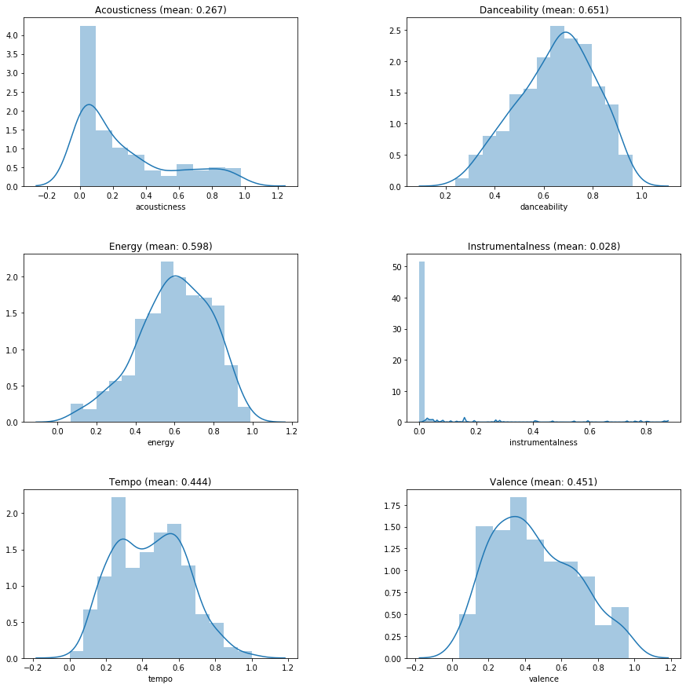

```python
fig = plt.figure()
fig.subplots_adjust(hspace=0.4, wspace=0.4)

fig.set_figheight(15)
fig.set_figwidth(15)

ax = fig.add_subplot(3, 2, 1)
ax.set_title("Acousticness" + " (mean: " + str(np.round(features['acousticness'].mean(), 3)) + ")")
sns.distplot(features['acousticness'],ax=ax)

ax = fig.add_subplot(3, 2, 2)
ax.set_title("Danceability" + " (mean: " + str(np.round(features['danceability'].mean(), 3)) + ")")
sns.distplot(features['danceability'])

ax = fig.add_subplot(3, 2, 3)
ax.set_title("Energy" + " (mean: " + str(np.round(features['energy'].mean(), 3)) + ")")
sns.distplot(features['energy'])

ax = fig.add_subplot(3, 2, 4)
ax.set_title("Instrumentalness" + " (mean: " + str(np.round(features['instrumentalness'].mean(), 3)) + ")")
sns.distplot(features['instrumentalness'])

ax = fig.add_subplot(3, 2, 5)
ax.set_title("Tempo" + " (mean: " + str(np.round(features['tempo'].mean(), 3)) + ")")
sns.distplot(features['tempo'])

ax = fig.add_subplot(3, 2, 6)
ax.set_title("Valence" + " (mean: " + str(np.round(features['valence'].mean(), 3)) + ")")
sns.distplot(features['valence'])
plt.show()
```

## Building Recommended Playlists

### Clustering

So now we've explored the songs in your library - let's start on finding some recommended songs. The first step to doing all this will be to cluster all of your saved tracks using the 6 audio features shown above. The idea here is that the clusters will represent the different types of songs that make up your library, which recommended songs can be matched with to see if they match your taste. Each cluster will get its own playlist of recommended songs, with each playlist hopefully containing similar songs while also having their own distinct sound. This relies a lot on Spotify having an accurate audio features analysis for each song, but we trust them.

Because we're clustering based on audio features and not just genre or artist, this will hopefully result in playlists that have a cohesive feel, but don't cover just one genre or style. A lot of people make "mood" playlists in this fashion, so we wanted to be able to do the same thing with recommended songs, for if you ever want to listen to new music with a specific mood instead of genre.

To do the actual clustering, we will use the popular [scikit-learn](https://scikit-learn.org/stable/index.html) library. It has a multitude of different clustering algorithms, but we chose to use Affinity Propagation for a few reasons: it does not require us to specify a certain number of clusters, and it has a predict function we can use to match new data to clusters (which we will use for recommended tracks). You can read more about how it works [here](https://scikit-learn.org/stable/modules/clustering.html#affinity-propagation), but the general idea is that it builds clusters by finding representatives for each cluster, which are iteratively updated by sending "messages" between data points (it's a lot of fancy math stuff, really). The important hyperparameter here is preference, which influences how many cluster representatives are chosen. If preference is really high, data points will want to be a cluster representative more strongly, thus more clusters will form. If its low, points will be more inclined to "give away" their cluster representative status, and fewer clusters will form.

While we don't know exactly how many clusters we want, we thought a good number would be between 6 and 10. If there were less than 6, the playlists would likely be too similar/nondistinct, while more than 10 would just be too many to listen to. To find the best number of playlists, we run affinity propagation with preferences starting at 0 and decreasing until it produces fewer than 6 clusters. To assess the quality of each clustering, we use the [Davies-Bouldin index](https://scikit-learn.org/stable/modules/generated/sklearn.metrics.davies_bouldin_score.html#sklearn.metrics.davies_bouldin_score), which broadly measures similarity between clusters (lower score = more distinct). Because we want our playlists to be as distinct as possible, we will choose the number of clusters that results in the lowest Davies-Bouldin index.

```python
affinity = cluster.AffinityPropagation(preference=0).fit(features.values)
pref = 0
db_scores = {}

while (len(affinity.cluster_centers_) > 6):
    #Running affinity propagation with decreasing preference each time
    pref -= 1
    affinity = cluster.AffinityPropagation(preference=pref).fit(features.values)

    #If between 6 and 10 clusters were formed, add the clustering's DBI to the scores dictionary
    if len(affinity.cluster_centers_) <= 10 and len(affinity.cluster_centers_) >= 6:
        db_scores[metrics.davies_bouldin_score(features.values, affinity.labels_)] = affinity

db_scores
```

```
{1.3673170641307981: AffinityPropagation(affinity='euclidean', convergence_iter=15, copy=True,
                     damping=0.5, max_iter=200, preference=-2, verbose=False),
 1.408757797905904: AffinityPropagation(affinity='euclidean', convergence_iter=15, copy=True,
                     damping=0.5, max_iter=200, preference=-3, verbose=False),
 1.342302253547328: AffinityPropagation(affinity='euclidean', convergence_iter=15, copy=True,
                     damping=0.5, max_iter=200, preference=-4, verbose=False)}
```

Now that we've found multiple clusterings, it's time to pick the best one to move forward with. By looking at the above output, we can see the lowest DBI was 1.342, so we will want to use its corresponding clustering in the db_scores map. To do this automatically, we can calculate the minimum value among the keys, then store its corresponding clustering in the "clusters" variable. Each songs' cluster assignment can be retrieved with the labels attribute, and the indices of the cluster representatives can be found with cluster_centers_indices. By using these indices with the pandas iloc function, we can see which songs are our cluster representatives. A total of 6 clusters were found for our dataset, but yours might be different. How do your cluster representatives look? Are the songs fairly distinct? That's the goal.

```python
#Getting the clustering with the lowest Davies-Bouldin index
clusters = db_scores[min(db_scores.keys())]

#Adding cluster labels to our dataframes
features['Cluster'] = clusters.labels_
track_info['Cluster'] = clusters.labels_

#Printing the cluster representatives
track_info.iloc[clusters.cluster_centers_indices_]
```

|  | title | artist | uri | Cluster |
| --- | --- | --- | --- | --- |
| 68 | Possible | Sincerely Collins | spotify:artist:0IdNIDCxQzqssxNQj3CeCD | 0 |
| 170 | Welcome Home, Son | Radical Face | spotify:artist:5EM6xJN2QNk0cL7EEm9HR9 | 1 |
| 250 | Ivy | Frank Ocean | spotify:artist:2h93pZq0e7k5yf4dywlkpM | 2 |
| 255 | Sanguine Paradise | Lil Uzi Vert | spotify:artist:4O15NlyKLIASxsJ0PrXPfz | 3 |
| 270 | Graduation (with Juice WRLD) | benny blanco | spotify:artist:5CiGnKThu5ctn9pBxv7DGa | 4 |
| 316 | Breakeven | The Script | spotify:artist:3AQRLZ9PuTAozP28Skbq8V | 5 |

If you want to see the songs in each cluster, you can adjust the number in the call to loc (and remove the call to head).

```python
#Can play with this to see the songs in each cluster
track_info.loc[track_info['Cluster'] == 0].head(10)
```

|  | title | artist | uri | Cluster |
| --- | --- | --- | --- | --- |
| 4 | Am I Wrong | Nico & Vinz | spotify:artist:0awl5piYwO0CDTHEkCjUhn | 0 |
| 25 | Yesterday | Atmosphere | spotify:artist:1GAS0rb4L8VTPvizAx2O9J | 0 |
| 31 | The Nosebleed Section | Hilltop Hoods | spotify:artist:7dlqUnjoF2U2DkNDMhcgG4 | 0 |
| 45 | Please Mr. Postman - Single Version / Mono | The Marvelettes | spotify:artist:0MponVSpW81oLvJZ53vYZH | 0 |
| 57 | Love Me Now | John Legend | spotify:artist:5y2Xq6xcjJb2jVM54GHK3t | 0 |
| 63 | I Feel It Coming | The Weeknd | spotify:artist:1Xyo4u8uXC1ZmMpatF05PJ | 0 |
| 64 | Caroline | Aminé | spotify:artist:3Gm5F95VdRxW3mqCn8RPBJ | 0 |
| 68 | Possible | Sincerely Collins | spotify:artist:0IdNIDCxQzqssxNQj3CeCD | 0 |
| 80 | Forever | P-Square | spotify:artist:42IUN9kTPdUdI1kre6L7Wk | 0 |
| 85 | Closer | The Chainsmokers | spotify:artist:69GGBxA162lTqCwzJG5jLp | 0 |

### PCA & Cluster Visualization

Now that we have our clustering, we want to be able to visualize the clusters, but unless you have a brain capable of comprehending 6d-space, our current features matrix isn't going to cut it. To plot our songs in 2d-space, we can decompose our features matrix into 2 components using [principal component analysis (PCA)](https://scikit-learn.org/stable/modules/decomposition.html#pca), which uses matrix algebra to reduce the dimensions of the matrix into features that explain the most variance in the data (if you know what a singular value decomposition is, that link might be of interest to you). The result of the decomposition is stored in the features_2d dataframe, which we can also attach the cluster labels to. The newly-transformed data points are shown in the output, along with the explained variance ratio for each of our two features. These values indicate how much of the variance in our data these two components are able to explain. Our data resulted in values of 0.436 and 0.223 - not particularly high, but that's understandable moving from 6d to 2d-space.

```python
#Performing the decomposition into 2 components (need to make sure cluster itself isn't used as a feature)
pca = decomposition.PCA(n_components=2)
features_2d = pd.DataFrame(pca.fit_transform(features.loc[:,:'valence']), columns=['Component 1', 'Component 2'])

#Adding cluster labels to our new dataframe to be used in the following scatterplot
features_2d['Cluster'] = clusters.labels_
print(pca.explained_variance_ratio_)
features_2d.head(10)
```

```
[0.43554842 0.22340241]
```

|  | Component 1 | Component 2 | Cluster |
| --- | --- | --- | --- |
| 0 | -0.013228 | -0.006005 | 5 |
| 1 | 0.676086 | -0.115102 | 2 |
| 2 | -0.355428 | 0.031180 | 4 |
| 3 | -0.296899 | -0.079487 | 5 |
| 4 | -0.221111 | 0.246697 | 0 |
| 5 | -0.249048 | -0.279736 | 3 |
| 6 | -0.176132 | -0.052761 | 4 |
| 7 | 0.748881 | 0.282385 | 2 |
| 8 | -0.079194 | 0.153039 | 4 |
| 9 | -0.194912 | -0.133856 | 3 |

Now that we have all our songs reduced to 2 features, we can plot them together on a scatterplot, with colors to indicate their cluster. Looking at our graph, there is a fair amount of overlap in our clustering: cluster 1 is just a few points inside cluster 2, and the remaining clusters are all grouped together on the left side of the graph. Clusters 0 and 3 are a bit more separate from the others though. While this isn't too promising for the quality of our clustering, it is important to remember that this is a projection of 6d points onto 2d-space, so a fair amount of distinction between them is lost (we already know this by looking at the explained variance ratios). The clusters in their 6d-reality are probably much more distinct than shown here.

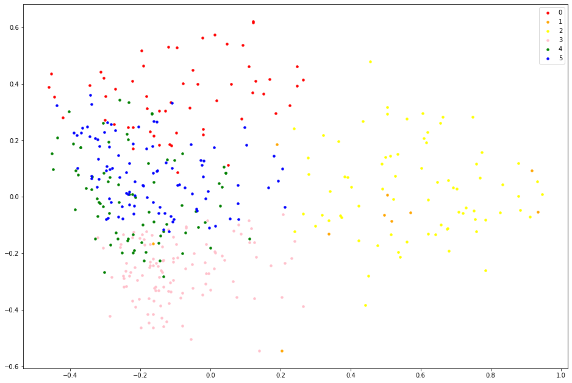

```python
colors = ['red', 'orange', 'yellow', 'pink', 'green', 'blue', 'purple', 'black', 'cyan', 'grey']
fig, ax = plt.subplots(figsize=(16,11))
features_2d = features_2d.sort_values('Cluster')

for cluster_label in features_2d['Cluster'].unique():
    group = features_2d.loc[features_2d['Cluster'] == cluster_label]
    ax.scatter(group['Component 1'], group['Component 2'], c = colors[cluster_label], label=cluster_label, s=12)

ax.legend()
```

It'll also be interesting to look at how the clusters differ in their distributions of audio features. To do this we can use the seaborn library to make [violin plots](https://seaborn.pydata.org/generated/seaborn.violinplot.html) Each of the following violin plots are for one feature, where each violin represents a cluster (the cluster labels are shown on the bottom row). If you aren't familiar with how a violin plot works, it displays the distribution of the y-value (in this case an audio feature) for each cluster, plotted side by side so we can compare their distributions. It's essentially a cooler looking boxplot.

The plots allow us to see which features "define" or are most unique to each cluster. For example, it appears that pretty much every song with high instrumentalness went into cluster 1, while every cluster has a fairly widespread distribution of danceabilities. While many clusters have similar distributions for multiple features, there is typically at least one feature that makes each one distinct.

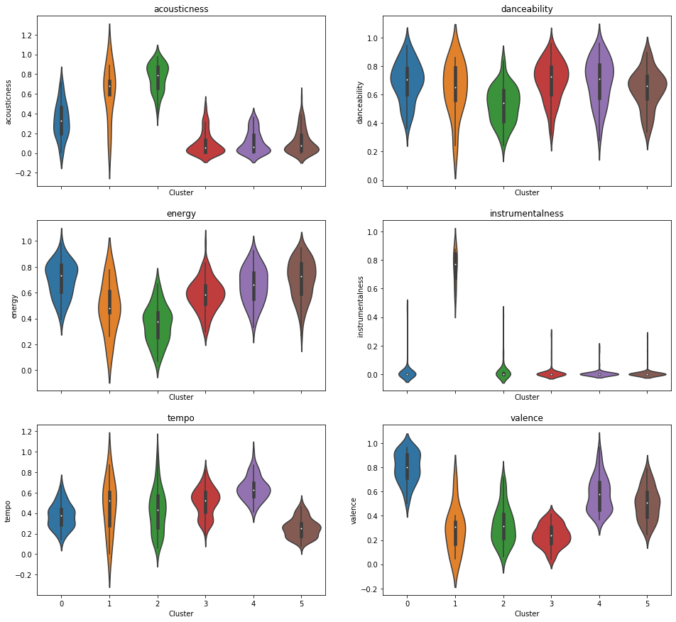

```python
#Creating a 3x2 grid for the violin plots
fig, ax = plt.subplots(3, 2, sharex=True, figsize=(16, 15))
ax = ax.flatten()
idx = 0

#For each feature (column in the features dataframe), plot its distribution for each cluster
for col in features.loc[:,:'valence'].columns:
    sns.violinplot(features['Cluster'], features[col], ax=ax[idx])
    ax[idx].set_title(col)
    idx += 1
```

This next set of violin plots is essentially the inverse of the above plots: for each cluster, we plot the distribution of each feature (labeled on the x-axis of the bottom row). This allows us to easily see what features define each cluster. For example, cluster 0 is a high-danceability, high-energy, low-instrumentalness, high-valence cluster. Clusters 0, 3, 4, and 5 have fairly similar distributions, but are hopefully distinct enough to produce unique playlists.

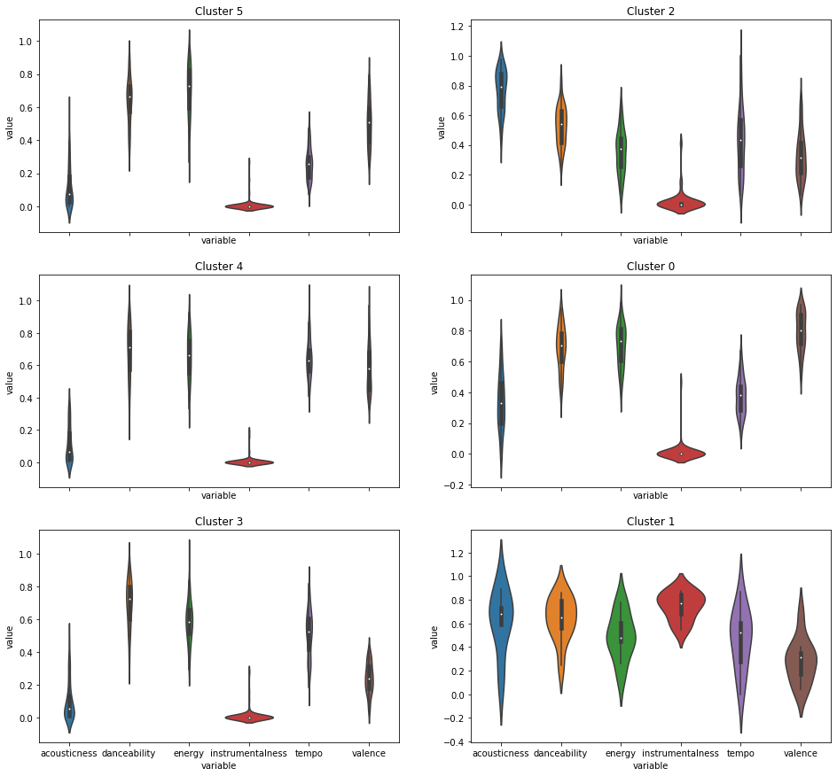

```python
#Creating a variable length grid based on the number of clusters
fig, ax = plt.subplots(int((len(clusters.cluster_centers_ + 1))/2), 2, sharex=True, figsize=(16, 15))
ax = ax.flatten()
idx = 0

#Creating a violin plot for each cluster label
for cluster_label in features['Cluster'].unique():
    group = features.loc[features['Cluster'] == cluster_label].drop('Cluster', axis=1)

    #Have to melt the data so that the features become variables in the dataframe, not columns
    group = group.melt()
    sns.violinplot(x=group['variable'], y=group['value'], data=group, ax=ax[idx])
    ax[idx].set_title("Cluster " + str(cluster_label))
    idx += 1
```

### Finding Similar Songs

Now that we've clustered your favorite tracks, it's time to find recommended tracks to match with these clusters. In this section, we'll match top tracks from similar artists to the clusters, then create playlists for each one with the most similar songs. The end result will be a set of playlists, each one consisting of new songs with a similar sound/feel.

To start, we need to decide what artists to use to get recommended songs. To do this, we can use the track_info dataframe to find the artists that occur most frequently in your saved tracks. A standard group-by/aggregate function (in this case our aggregate is count) will accomplish this. The result is stored in the artists dataframe, which we can take the top 25 artists from to use for recommendations. We also add the artist's uri as a column to the dataframe to make the next section easier.

```python
#Getting the number of tracks for each artist in your library
artists = track_info.groupby('artist').count().drop(['Cluster', 'uri'], axis=1)
artists = artists.reset_index().rename(columns={"title": "count"})

#Sorting it to find the top 25 then getting the uri from the track_info table
artists = artists.sort_values('count', ascending=False).head(25)
artists['uri'] = [track_info.loc[track_info['artist'] == artist].iloc[0]['uri'] for artist in artists['artist']]
artists.head(5)
```

|  | artist | count | uri |
| --- | --- | --- | --- |
| 51 | Drake | 21 | spotify:artist:3TVXtAsR1Inumwj472S9r4 |
| 197 | The Weeknd | 20 | spotify:artist:1Xyo4u8uXC1ZmMpatF05PJ |
| 22 | Bon Iver | 18 | spotify:artist:4LEiUm1SRbFMgfqnQTwUbQ |
| 78 | Hozier | 10 | spotify:artist:2FXC3k01G6Gw61bmprjgqS |
| 69 | Future | 10 | spotify:artist:1RyvyyTE3xzB2ZywiAwp0i |

To find recommended songs, we can use the Spotify API to get similar artists for each of your top artists, then get the top tracks for those artists. The name, artist, and uri for the recommended tracks are stored in the related_tracks dataframe. To make sure the same artists don't get recommended to you, we use the known_artists set to store the artists that are either already in your library or that have already been recommended.

Because we took the top 25 artists above, are getting 12 similar artists for each of them, and are getting 5 top tracks for each similar artist, the maximum number of recommended songs we can find here is 1500. However, due to duplicate recommendations, the actual number will be lower than this - we only found 904 for our dataset. If you want more (or less), you can easily adjust the numbers in the code.

```python
related_tracks = []
known_artists = set(track_info['artist'])

for tup in artists.itertuples():
    #Call to Spotify API for similar artists (takes the top 12)
    for artist in sp.artist_related_artists(tup.uri)['artists'][:12]:

        #Making sure artist hasn't been seen before
        if artist['name'] not in known_artists:
            known_artists.add(artist['name'])

            #Call to Spotify API for the artist's top tracks
            for track in sp.artist_top_tracks(artist['uri'])['tracks'][:5]:
                related_tracks.append([track['name'], track['artists'][0]['name'], track['uri']])

related_tracks = pd.DataFrame(related_tracks).rename(columns={0: "title", 1: "artist", 2: "uri"})
related_tracks.head(10)
```

|  | title | artist | uri |
| --- | --- | --- | --- |
| 0 | Bezerk (feat. A$AP Ferg & Hit-Boy) | Big Sean | spotify:track:2B9wgj9XzbJZLty03PRbVo |
| 1 | Bounce Back | Big Sean | spotify:track:0SGkqnVQo9KPytSri1H6cF |
| 2 | I Don't Fuck With You | Big Sean | spotify:track:7FYH5AW3bVfZHJIQpq3UOA |
| 3 | Single Again | Big Sean | spotify:track:7IP0lO9tHfNwBWZ9X6TJ84 |
| 4 | Jump Out The Window | Big Sean | spotify:track:1jQsKN68yE94tMYml0wHMd |
| 5 | oui | Jeremih | spotify:track:0PJIbOdMs3bd5AT8liULMQ |
| 6 | Impatient | Jeremih | spotify:track:3WjyiSbfR74pjWXQ3IaFKJ |
| 7 | Don't Tell 'Em | Jeremih | spotify:track:0Dc7J9VPV4eOInoxUiZrsL |
| 8 | Planez | Jeremih | spotify:track:08zJpaUQVi9FrKv2e32Bah |
| 9 | All The Time | Jeremih | spotify:track:0USZx50eApN045zIIyjePN |

Now we need to find the audio features for each recommended track, similar to what we did at the very beginning for your saved tracks. Like before, we make a call to the Spotify API to get the features for each track, add it to the rec_features array, then turn that into a dataframe, only keeping the same 6 features we chose before. We also have to normalize tempo again to be between 0 and 1.

```python
rec_features = []

for uri in related_tracks['uri']:
    #Call to Spotify API for audio features for each recommended track
    rec_features.extend(sp.audio_features(uri))

rec_features = pd.DataFrame(rec_features)
rec_features = rec_features[['acousticness', 'danceability', 'energy', 'instrumentalness', 'tempo', 'valence']]

#Min-max normalization of tempo
rec_features['tempo'] = (rec_features['tempo']-rec_features['tempo'].min())/ \
                        (rec_features['tempo'].max()-rec_features['tempo'].min())
rec_features.head(10)
```

|  | acousticness | danceability | energy | instrumentalness | tempo | valence |
| --- | --- | --- | --- | --- | --- | --- |
| 0 | 0.0164 | 0.684 | 0.687 | 0.000000 | 0.821576 | 0.2650 |
| 1 | 0.1040 | 0.780 | 0.574 | 0.000000 | 0.139801 | 0.2730 |
| 2 | 0.0355 | 0.824 | 0.733 | 0.000000 | 0.249318 | 0.3930 |
| 3 | 0.1610 | 0.635 | 0.677 | 0.000000 | 0.229229 | 0.2530 |
| 4 | 0.1360 | 0.747 | 0.704 | 0.000000 | 0.508432 | 0.4940 |
| 5 | 0.2130 | 0.418 | 0.724 | 0.000000 | 0.119978 | 0.6040 |
| 6 | 0.1060 | 0.697 | 0.400 | 0.000000 | 0.788200 | 0.4430 |
| 7 | 0.3920 | 0.856 | 0.527 | 0.000000 | 0.249857 | 0.3860 |
| 8 | 0.7000 | 0.688 | 0.556 | 0.000002 | 0.457893 | 0.4160 |
| 9 | 0.5450 | 0.675 | 0.440 | 0.000006 | 0.328133 | 0.0338 |

Now it's time for the interesting part - matching the recommended songs to clusters, then finding the closest matches. To get each song's closest cluster, we can use the predict function for affinity propagation. To find how well a song fits into its cluster, we can find its sihouette score, which you can read about more [here](https://scikit-learn.org/stable/modules/generated/sklearn.metrics.silhouette_samples.html#sklearn.metrics.silhouette_samples). In short, the silhouette score calculates how close a data point is to the other members in its cluster relative to the nearest cluster it is not a part of. It is a value between 0 and 1, where higher values indicate data points more similar to their cluster.

```python
#Adding a column for each recommended song's predicted cluster
rec_features['cluster'] = clusters.predict(rec_features)

#Adding a column for each recommended song's silhouette score
rec_features['silhouette'] = metrics.silhouette_samples(rec_features.loc[:'valence'], rec_features['cluster'])

#Adding columns for each recommended song's title, artist, and uri
rec_features[['title', 'artist', 'uri']] = related_tracks[['title', 'artist', 'uri']]
rec_features.head(10)
```

|  | acousticness | danceability | energy | instrumentalness | tempo | valence | cluster | silhouette | title | artist | uri |
| --- | --- | --- | --- | --- | --- | --- | --- | --- | --- | --- | --- |
| 0 | 0.0164 | 0.684 | 0.687 | 0.000000 | 0.821576 | 0.2650 | 3 | 0.576491 | Bezerk (feat. A$AP Ferg & Hit-Boy) | Big Sean | spotify:track:2B9wgj9XzbJZLty03PRbVo |
| 1 | 0.1040 | 0.780 | 0.574 | 0.000000 | 0.139801 | 0.2730 | 5 | 0.682310 | Bounce Back | Big Sean | spotify:track:0SGkqnVQo9KPytSri1H6cF |
| 2 | 0.0355 | 0.824 | 0.733 | 0.000000 | 0.249318 | 0.3930 | 5 | 0.694847 | I Don't Fuck With You | Big Sean | spotify:track:7FYH5AW3bVfZHJIQpq3UOA |
| 3 | 0.1610 | 0.635 | 0.677 | 0.000000 | 0.229229 | 0.2530 | 5 | 0.692447 | Single Again | Big Sean | spotify:track:7IP0lO9tHfNwBWZ9X6TJ84 |
| 4 | 0.1360 | 0.747 | 0.704 | 0.000000 | 0.508432 | 0.4940 | 4 | 0.679739 | Jump Out The Window | Big Sean | spotify:track:1jQsKN68yE94tMYml0wHMd |
| 5 | 0.2130 | 0.418 | 0.724 | 0.000000 | 0.119978 | 0.6040 | 5 | 0.640375 | oui | Jeremih | spotify:track:0PJIbOdMs3bd5AT8liULMQ |
| 6 | 0.1060 | 0.697 | 0.400 | 0.000000 | 0.788200 | 0.4430 | 4 | 0.567976 | Impatient | Jeremih | spotify:track:3WjyiSbfR74pjWXQ3IaFKJ |
| 7 | 0.3920 | 0.856 | 0.527 | 0.000000 | 0.249857 | 0.3860 | 5 | 0.625076 | Don't Tell 'Em | Jeremih | spotify:track:0Dc7J9VPV4eOInoxUiZrsL |
| 8 | 0.7000 | 0.688 | 0.556 | 0.000002 | 0.457893 | 0.4160 | 2 | 0.648365 | Planez | Jeremih | spotify:track:08zJpaUQVi9FrKv2e32Bah |
| 9 | 0.5450 | 0.675 | 0.440 | 0.000006 | 0.328133 | 0.0338 | 2 | 0.554893 | All The Time | Jeremih | spotify:track:0USZx50eApN045zIIyjePN |

Because we want the songs in our playlists to be similar to one another but different from those in other playlists, we will take the songs with the highest silhouette score from each cluster to build the playlists with. To do this, we can group the dataframe by cluster, sort them by silhouette score, then take the top 12 songs from each one (this is another number that can be adjusted if you want more/less songs). The result is stored in the dataframe called grouped.

The output shown here is the average silhouette score for each cluster. In our case, most of them are fairly high (around 0.7), so we can expect those to be fairly cohesive and distinct playlists (assuming Spotify has an accurate analysis of these songs' features). Cluster 1, however, has a lower score, so that will likely be the weakest playlist of the bunch.

```python
grouped = rec_features.groupby('cluster').apply(lambda x: x.sort_values('silhouette', ascending=False).head(12))
grouped = grouped.reset_index(drop=True)

grouped.groupby('cluster').mean()['silhouette']
```

```
cluster
0    0.776553
1    0.504477
2    0.688332
3    0.721089
4    0.710572
5    0.728675
Name: silhouette, dtype: float64
```

This is just a line of code you can play with to see what songs are in each cluster's recommended playlist. Just change the cluster number in the call to loc.

```python
#Can play with this to see the songs in each playlist
grouped.loc[grouped['cluster'] == 1]
```

|  | acousticness | danceability | energy | instrumentalness | tempo | valence | cluster | silhouette | title | artist | uri |
| --- | --- | --- | --- | --- | --- | --- | --- | --- | --- | --- | --- |
| 12 | 0.53400 | 0.436 | 0.563 | 0.651 | 0.209758 | 0.2570 | 1 | 0.602248 | Downhill Lullaby | Sky Ferreira | spotify:track:5pTpFp9wr8X7uddedE7uJS |
| 13 | 0.80300 | 0.457 | 0.408 | 0.884 | 0.376205 | 0.1280 | 1 | 0.593194 | Anchor | Novo Amor | spotify:track:7qH9Z4dJEN0l9bidizW7fq |
| 14 | 0.66900 | 0.602 | 0.552 | 0.588 | 0.215816 | 0.3600 | 1 | 0.575912 | Forest Green | Big Red Machine | spotify:track:0WVCw4DuZ5GliVNUyyNmS2 |
| 15 | 0.78300 | 0.685 | 0.297 | 0.924 | 0.196292 | 0.2330 | 1 | 0.570215 | jasmine - demo | Jai Paul | spotify:track:2FDVRMuNMw1pz4d03zyrtQ |
| 16 | 0.67800 | 0.441 | 0.525 | 0.739 | 0.122797 | 0.5130 | 1 | 0.567082 | Yellowstone | S. Carey | spotify:track:6pTasKEpCfFTO5fcU4osAR |
| 17 | 0.92100 | 0.391 | 0.435 | 0.675 | 0.264799 | 0.0424 | 1 | 0.547944 | From Gold | Novo Amor | spotify:track:3AQhXfkD5BijatJVv2DsJV |
| 18 | 0.68300 | 0.529 | 0.298 | 0.503 | 0.143385 | 0.0966 | 1 | 0.524377 | Hallucinate | Oliver Riot | spotify:track:0qnSjipvB268SHMbNSxZ7y |
| 19 | 0.94200 | 0.252 | 0.314 | 0.676 | 0.096936 | 0.2000 | 1 | 0.510474 | Visions of Gideon | Sufjan Stevens | spotify:track:5c9qm0bMYawSyRNUTmUMs5 |
| 20 | 0.16900 | 0.706 | 0.613 | 0.706 | 0.402167 | 0.2290 | 1 | 0.486961 | Thrive | Yoe Mase | spotify:track:1APGWTwyWb3nbESCEbqiAu |
| 21 | 0.00108 | 0.735 | 0.686 | 0.871 | 0.402532 | 0.0656 | 1 | 0.429997 | Habits (Stay High) - Hippie Sabotage Remix | Tove Lo | spotify:track:62N2JSA0jHmSH7Va9t7hIf |
| 22 | 0.94000 | 0.365 | 0.273 | 0.431 | 0.477503 | 0.2380 | 1 | 0.409171 | Mystery of Love (From the Original Motion Pict... | Sufjan Stevens | spotify:track:0oTtnnedK0C4unALxVTPhz |
| 23 | 0.09140 | 0.626 | 0.645 | 0.792 | 0.449773 | 0.9110 | 1 | 0.236147 | Lemon Firebrigade | Haircut 100 | spotify:track:1WrsjQWhtJkKZ5wWcaZYwN |

Like we did for our initial clustering, we would like to visualize where all our recommended songs lie relative to each other. We can perform the same PCA decomposition to 2 features that we did before, then plot each point in 2d space labeled by cluster. While not perfect, the clusters actually appear fairly distinct (even in the blob in the bottom left, they seem to take up mostly non-overlapping areas). This is promising for the quality of our recommended playlists. Cluster 1 (orange) is the only widely dispersed one, which is why its silhouette score was so low.

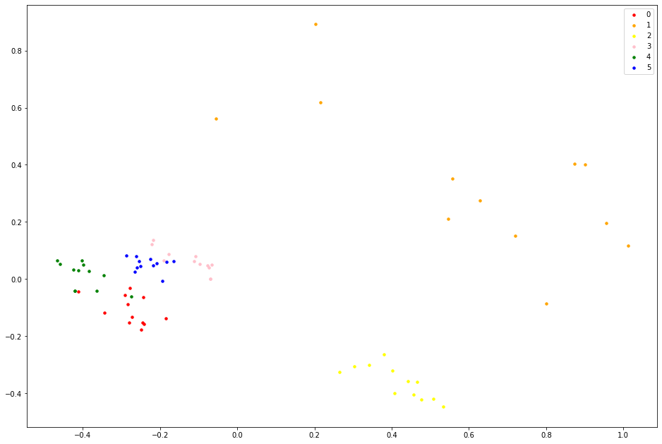

```python
#Performing PCA and storing results in features_2d
features_2d = pd.DataFrame(pca.fit_transform(grouped.loc[:,:'valence']), columns=['Component 1', 'Component 2'])
features_2d['cluster'] = grouped['cluster']

fig, ax = plt.subplots(figsize=(16,11))
features_2d = features_2d.sort_values('cluster')

#Getting the points for each cluster and adding to scatterplot with color corresponding to cluster
for cluster_label in features_2d['cluster'].unique():
    group = features_2d.loc[features_2d['cluster'] == cluster_label]
    ax.scatter(group['Component 1'], group['Component 2'], c = colors[cluster_label], label=cluster_label, s=12)

ax.legend()
```

You also might want to see how the features for our recommended tracks compare to the original tracks we used to build the clusters. To do this, we can take the saved tracks and recommended tracks in each cluster, calculate their averages for each feature, then plot them side by side in a bar graph. In the output below, each graph corresponds to one cluster, the x-axis corresponds to features (labeled on the bottom row of graphs), and the y-axis is the average value for each feature. We can see that the features line up pretty well for each cluster, which indicates that our recommended songs sound pretty similar to the saved tracks.

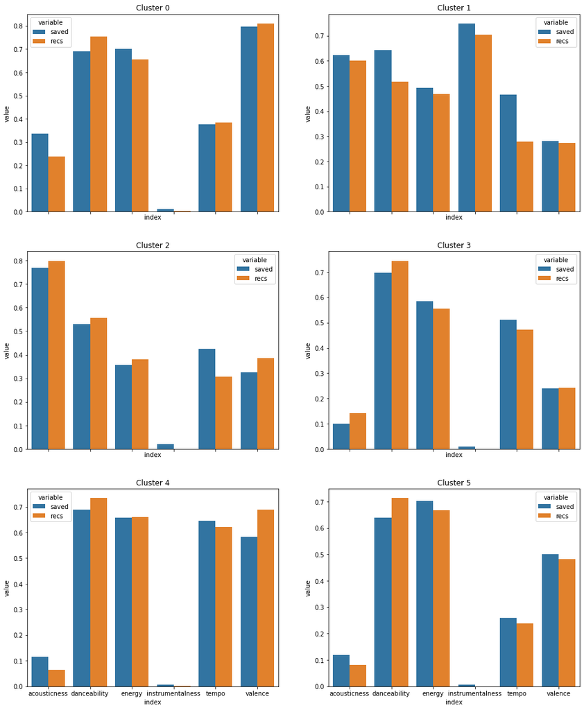

```python
fig, ax = plt.subplots(int((len(clusters.cluster_centers_ + 1))/2), 2, sharex=True, figsize=(16, 20))
ax = ax.flatten()
idx = 0

for cluster_label in grouped['cluster'].unique():
    #Getting the saved and recommended tracks for the cluster & calculating averages for each feature
    saved = features.loc[features['Cluster'] == cluster_label].loc[:,:'valence'].mean()
    recs = grouped.loc[grouped['cluster'] == cluster_label].loc[:,:'valence'].mean()

    #Combining the values into a dataframe to make it plottable with seaborn
    #Have to melt it so saved vs. recommended is a variable in the dataframe we can use to split the data
    combined = pd.DataFrame(saved).rename(columns={0: "saved"})
    combined['recs'] = recs
    combined = combined.reset_index().melt(id_vars=['index'])

    #Features on x-axis, average value on y-axis, hue splits it up by saved vs. recommended
    sns.barplot(x=combined['index'], y=combined['value'], hue=combined['variable'], data=group, ax=ax[idx])
    ax[idx].set_title("Cluster " + str(cluster_label))

    idx += 1
```

Now for the grand finale: actually creating the playlists! For this, all we need to do is get the group of recommended songs for each cluster, initialize the playlist, then pass in a list of the track URIs to the API call. This will automatically add the playlists to your library! The only extra thing here is coming up with a name for the playlists. We thought it made sense to label them by their most defining audio features, so we iterated over the average feature values for each cluster and added low/high values to the name. A value below 0.2 was considered low and above 0.65 considered high, but these values (or the entire naming scheme altogether) can be adjusted to fit your preferences.

Take some time to go check out your playlists! Hopefully you find something you like.

```python
for cluster_label in grouped['cluster'].unique():
    #Getting the recommended songs for each cluster
    cluster_rec = grouped.loc[grouped['cluster'] == cluster_label]

    #Don't want to consider cluster or silhouette in the naming
    feature_avgs = cluster_rec.mean().drop(['cluster', 'silhouette'])

    #Finding low/high features to add to the name
    name = ""
    for feature in feature_avgs.keys():
        if feature_avgs[feature] < 0.2:
            name += "Low " + feature + ", "
        elif feature_avgs[feature] > 0.65:
            name += "High " + feature + ", "
    name = name[:-2]

    #Creating the playlists!
    playlist = sp.user_playlist_create('12124976904', name)
    sp.user_playlist_add_tracks(username, playlist['id'], cluster_rec['uri'])
```

## Takeaways

Happy Coding!